# ARIMA Assignment

Vatsal Jani

2023-12-04

```r
library(readr)
Time_series_data <- read_csv("C:/Users/vatsal.jani/OneDrive - Catalent/Desktop/MBA/Business forecasting/Assignments/Time series data.csv")
View(Time_series_data)
```

```r
Data <- data.frame(Time_series_data$Period, Time_series_data$Revenue)
Data
```

```
##    Time_series_data.Period Time_series_data.Revenue
## 1               01.01.2015                 16010072
## 2               01.02.2015                 15807587
## 3               01.03.2015                 22047146
## 4               01.04.2015                 18814583
## 5               01.05.2015                 14021480
## 6               01.06.2015                 16783929
## 7               01.07.2015                 19161892
## 8               01.08.2015                 15204984
## 9               01.09.2015                 20603940
## 10              01.10.2015                 20992875
## 11              01.11.2015                 14993370
## 12              01.12.2015                 27791808
## 13              01.01.2016                 28601587
## 14              01.02.2016                 22367074
```

[output cut: 50 more lines]

```r
myts <- ts(Data[,-1], start=2015, end=2020, frequency=12)
myts
```

```
##           Jan      Feb      Mar      Apr      May      Jun      Jul      Aug
## 2015 16010072 15807587 22047146 18814583 14021480 16783929 19161892 15204984
## 2016 28601587 22367074 29738609 28351008 15264604 24385658 29486517 15270117
## 2017 36007381 30396775 47678131 27013965 24948845 31101346 33848822 16454667
## 2018 44067521 36020287 46995990 35536488 29699599 33261065 35826535 23268655
## 2019 36459960 36546499 54198707 32743990 32531658 47709702 45992142 36933665
## 2020 56288301
##           Sep      Oct      Nov      Dec
## 2015 20603940 20992875 14993370 27791808
## 2016 36141028 27915144 21272049 42014160
## 2017 31650093 31572206 22446371 44966126
## 2018 35423490 39831566 32999145 47221828
## 2019 48526260 44160416 36374956 58756474
## 2020
```

```r
library(ggplot2)
library(fpp)
library(fpp2)
library(forecast)
```

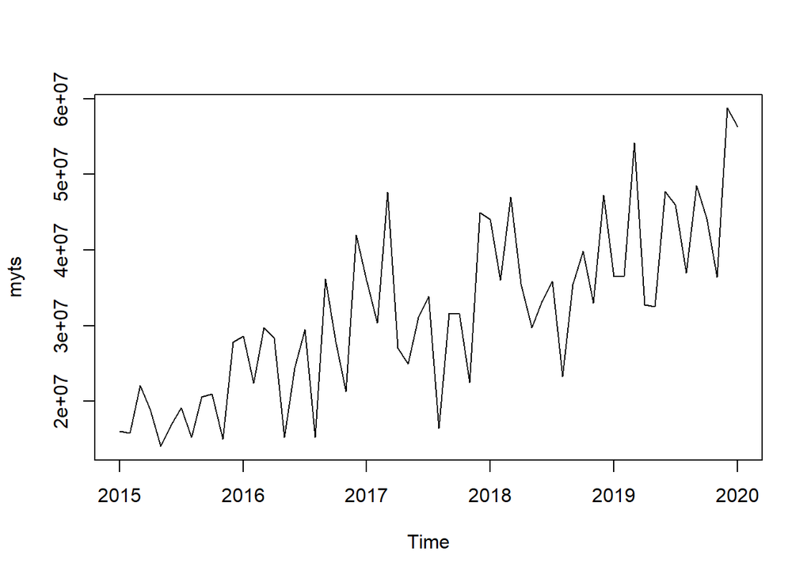

```r
plot(myts)
```

```r
kpss.test(myts)
```

```
##
##  KPSS Test for Level Stationarity
##
## data:  myts
## KPSS Level = 1.3907, Truncation lag parameter = 3, p-value = 0.01
```

```r
adf.test(myts)
```

```
##
##  Augmented Dickey-Fuller Test
##
## data:  myts
## Dickey-Fuller = -3.7028, Lag order = 3, p-value = 0.03203
## alternative hypothesis: stationary
```

#For KIPSS test, P value is less than 0.05, indicating that data is not staionary and differencing is required for this data to make it stationary. #For ADF test, P Value is less than 0.05, indicating that data is stationary and differencing is not required.

```r
ndiffs(myts)
```

```
## [1] 1
```

#ndiff value of 1 indicates that first order differencing is required.

```r
nsdiffs(myts)
```

```
## [1] 1
```

#nsdiff value of 1 indicates that seasonal differencing is required.

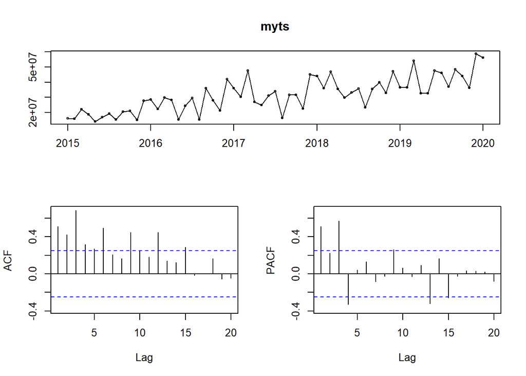

```r
tsdisplay(myts)
```

#ACF and Pacf plots show that there is some trend and seasonality in this data, which is increasing the variance and making data non-stationary. Hence, differencing is required.

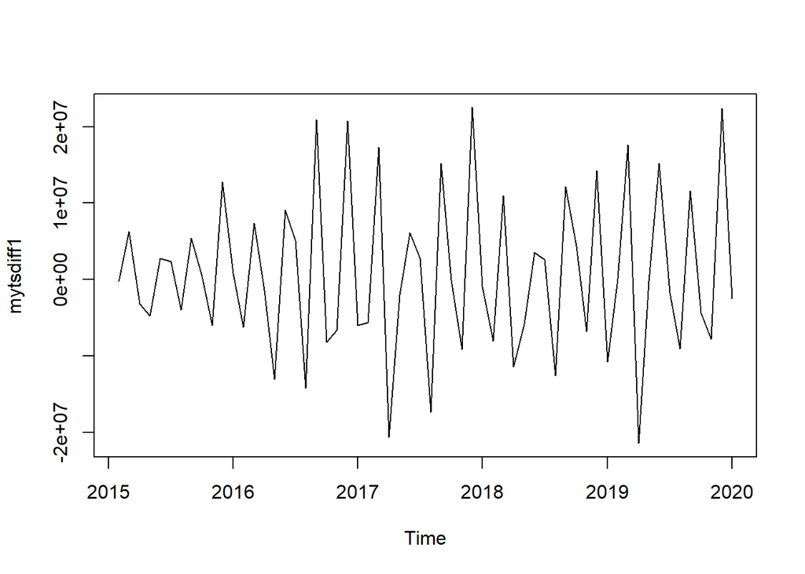

```r
mytsdiff1 <- diff(myts, differences=1)
plot(mytsdiff1)
```

#Upon doing first order differencing, variance is reduced and data has become somewhat stationary.

```r
kpss.test(mytsdiff1)
```

```
##
##  KPSS Test for Level Stationarity
##
## data:  mytsdiff1
## KPSS Level = 0.039106, Truncation lag parameter = 3, p-value = 0.1
```

```r
adf.test(mytsdiff1)
```

```
##
##  Augmented Dickey-Fuller Test
##
## data:  mytsdiff1
## Dickey-Fuller = -3.6509, Lag order = 3, p-value = 0.03651
## alternative hypothesis: stationary
```

```r
ndiffs(mytsdiff1)
```

```
## [1] 0
```

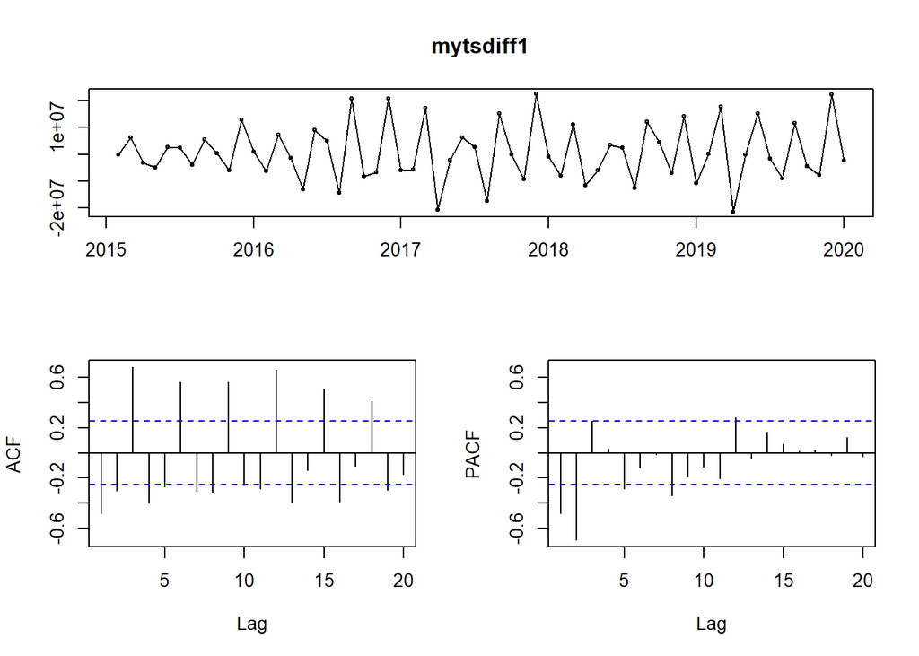

```r
tsdisplay(mytsdiff1)
```

#After differencing,P value of Kipps test becomes 0.1, indicationg that, time series has been stationarized. This is corroborated by ndiff value of 0. No more differencing is required. However, still seasonal factor is be evaluated for data.

```r
nsdiffs(mytsdiff1)
```

```
## [1] 1
```

#However, nsdiff value is still 1, which means first order seasonal differencing is still required.

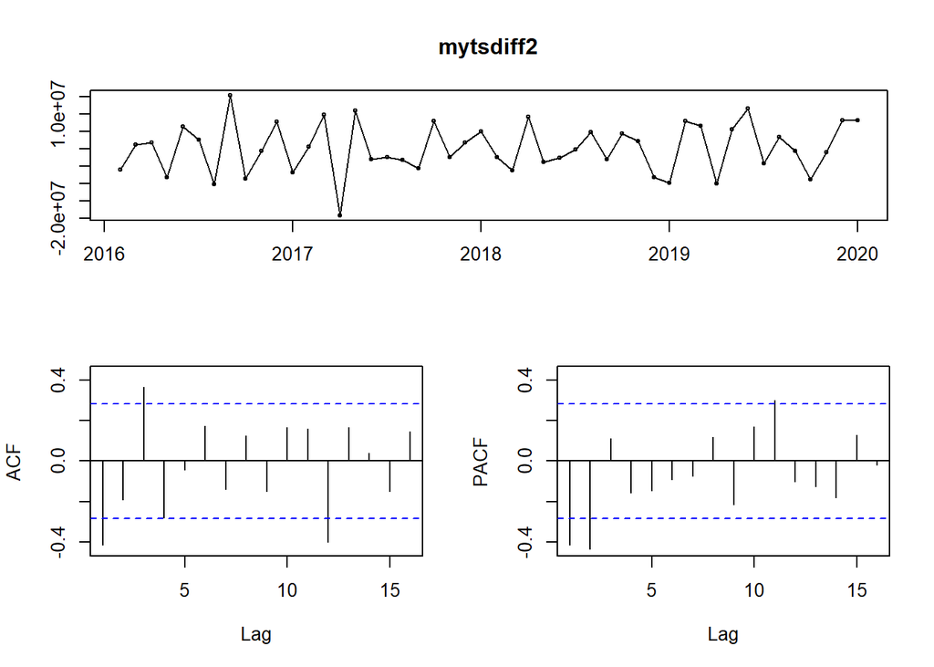

```r
mytsdiff2 <- diff(mytsdiff1,12)
tsdisplay(mytsdiff2)
```

```r
nsdiffs(mytsdiff2)
```

```
## [1] 0
```

#Upon performing first order seasonal differencing of time series, nsdiff value becomes 0, which means that data is completely staionarized and no more differencing is required.

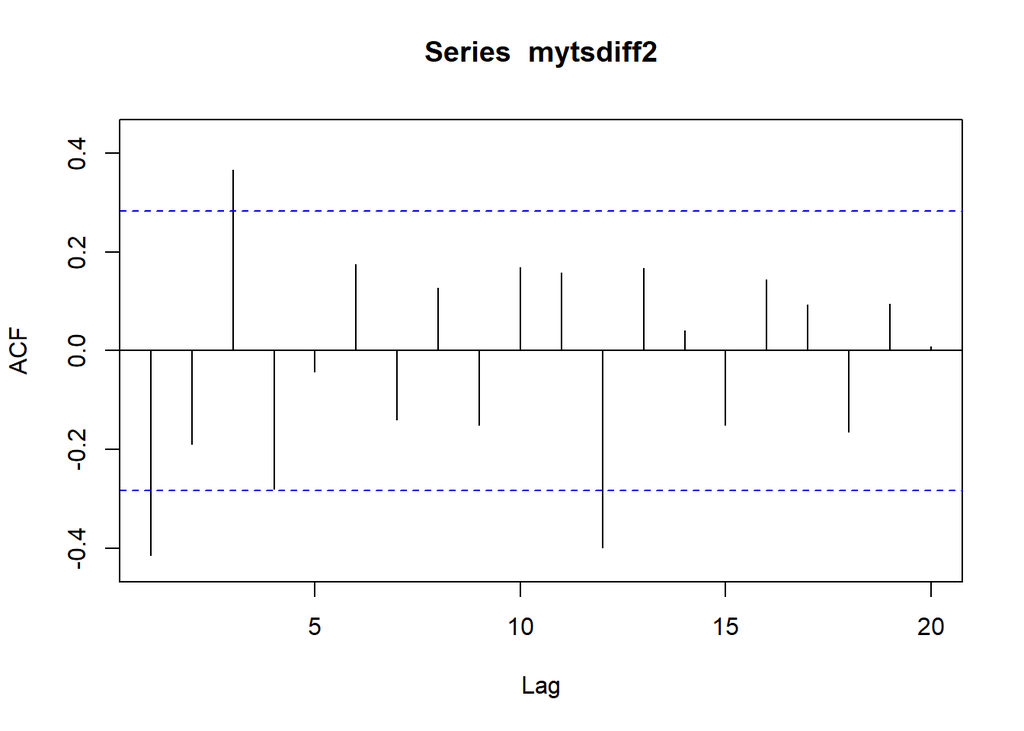

```r
Acf(mytsdiff2, lag.max=20)
```

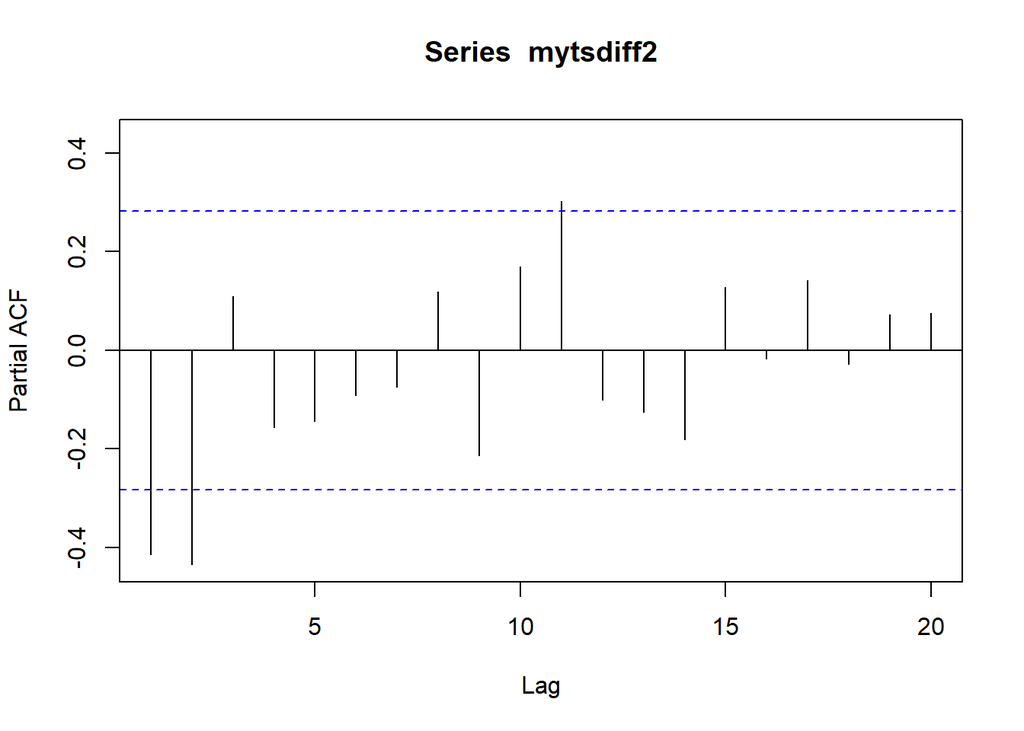

```r
Pacf(mytsdiff2, lag.max=20)
```

#, Pacf function gives significant values till lag 2 and it’s significantly decaying as well. Acf function gives significant value till lag 1 and lag 3, and it also seems to be exponentially decaying very slowly. Order of sequencing is already 1 for timeseries. so, possible order for Arima function (Considering it a non-seasonal data) can be (2,1,1) or(2,1,2) or (2,1,3).

```r
fit_Arima1 <- Arima(myts, order=c(2,1,1))
fit_Arima1
```

```
## Series: myts
## ARIMA(2,1,1)
##
## Coefficients:
##           ar1      ar2     ma1
##       -0.9367  -0.7767  0.2742
## s.e.   0.0980   0.0809  0.1330
##
## sigma^2 = 4.322e+13:  log likelihood = -1026.42
## AIC=2060.84   AICc=2061.57   BIC=2069.22
```

```r
fit_Arima2 <- Arima(myts, order=c(2,1,2))
fit_Arima2
```

```
## Series: myts
## ARIMA(2,1,2)
##
## Coefficients:
##           ar1      ar2     ma1     ma2
##       -0.9644  -0.9376  0.4875  0.5463
## s.e.   0.0544   0.0502  0.1568  0.1405
##
## sigma^2 = 3.829e+13:  log likelihood = -1022.66
## AIC=2055.32   AICc=2056.43   BIC=2065.79
```

```r
auto_fit <- auto.arima(myts, trace=TRUE, stepwise = FALSE, seasonal=FALSE, approximation=FALSE)
```

```
##
##  ARIMA(0,1,0)                               : 2113.33
##  ARIMA(0,1,0)            with drift         : 2115.23
##  ARIMA(0,1,1)                               : 2084.784
##  ARIMA(0,1,1)            with drift         : Inf
##  ARIMA(0,1,2)                               : 2085.032
##  ARIMA(0,1,2)            with drift         : Inf
##  ARIMA(0,1,3)                               : Inf
##  ARIMA(0,1,3)            with drift         : Inf
##  ARIMA(0,1,4)                               : 2073.913
##  ARIMA(0,1,4)            with drift         : Inf
##  ARIMA(0,1,5)                               : 2074.686
##  ARIMA(0,1,5)            with drift         : Inf
##  ARIMA(1,1,0)                               : 2100.417
##  ARIMA(1,1,0)            with drift         : 2101.921
##  ARIMA(1,1,1)                               : 2086.329
##  ARIMA(1,1,1)            with drift         : Inf
##  ARIMA(1,1,2)                               : 2085.163
##  ARIMA(1,1,2)            with drift         : Inf
##  ARIMA(1,1,3)                               : Inf
##  ARIMA(1,1,3)            with drift         : 2081.544
##  ARIMA(1,1,4)                               : 2076.309
##  ARIMA(1,1,4)            with drift         : Inf
##  ARIMA(2,1,0)                               : 2062.894
##  ARIMA(2,1,0)            with drift         : 2062.248
##  ARIMA(2,1,1)                               : 2061.571
##  ARIMA(2,1,1)            with drift         : 2061.564
##  ARIMA(2,1,2)                               : 2056.434
##  ARIMA(2,1,2)            with drift         : Inf
##  ARIMA(2,1,3)                    : Inf
##  ARIMA(2,1,3)            with drift         : Inf
##  ARIMA(3,1,0)                               : 2059.877
##  ARIMA(3,1,0)            with drift         : 2060.384
##  ARIMA(3,1,1)                               : 2062.187
##  ARIMA(3,1,1)            with drift         : 2062.834
##  ARIMA(3,1,2)                               : Inf
##  ARIMA(3,1,2)            with drift         : Inf
##  ARIMA(4,1,0)                               : 2062.046
##  ARIMA(4,1,0)            with drift         : 2062.777
##  ARIMA(4,1,1)                               : 2062.928
##  ARIMA(4,1,1)            with drift         : Inf
##  ARIMA(5,1,0)                               : 2060.002
##  ARIMA(5,1,0)            with drift         : 2059.632
##
##
##
##  Best model: ARIMA(2,1,2)
```

```r
auto_fit
```

```
## Series: myts
## ARIMA(2,1,2)
##
## Coefficients:
##           ar1      ar2     ma1     ma2
##       -0.9644  -0.9376  0.4875  0.5463
## s.e.   0.0544   0.0502  0.1568  0.1405
##
## sigma^2 = 3.829e+13:  log likelihood = -1022.66
## AIC=2055.32   AICc=2056.43   BIC=2065.79
```

```r
attributes(auto_fit)
```

```
## $names
##  [1] "coef"      "sigma2"    "var.coef"  "mask"      "loglik"    "aic"
##  [7] "arma"      "residuals" "call"      "series"    "code"      "n.cond"
## [13] "nobs"      "model"     "bic"       "aicc"      "x"         "fitted"
##
## $class
## [1] "forecast_ARIMA" "ARIMA"          "Arima"
```

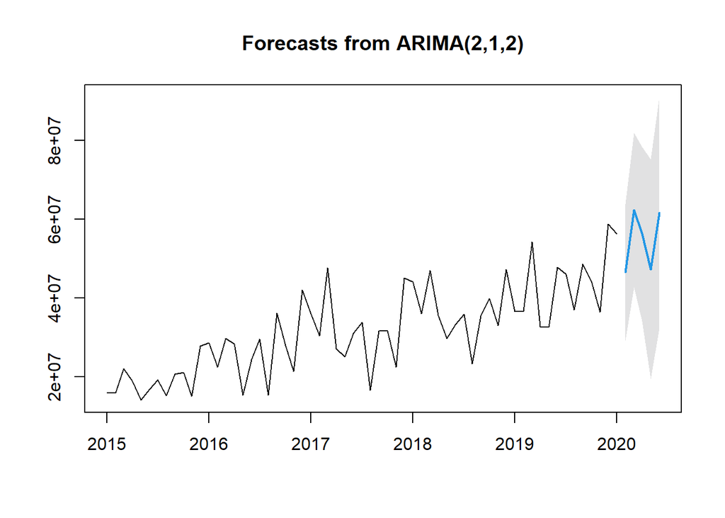

```r
fcast <- forecast(auto_fit,h=5,level=c(99.5))
plot(fcast)
```

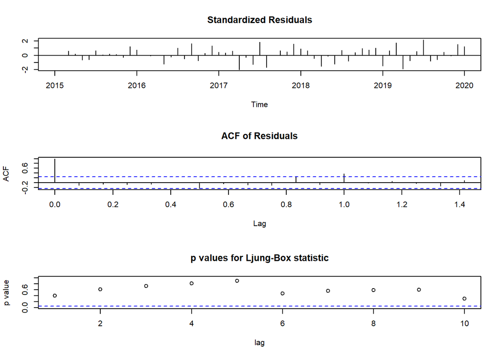

```r
tsdiag(auto_fit)
```

```r
Box.test(residuals(auto_fit), lag=20, type="Ljung")
```

```
##
##  Box-Ljung test
##
## data:  residuals(auto_fit)
## X-squared = 29.981, df = 20, p-value = 0.07017
```

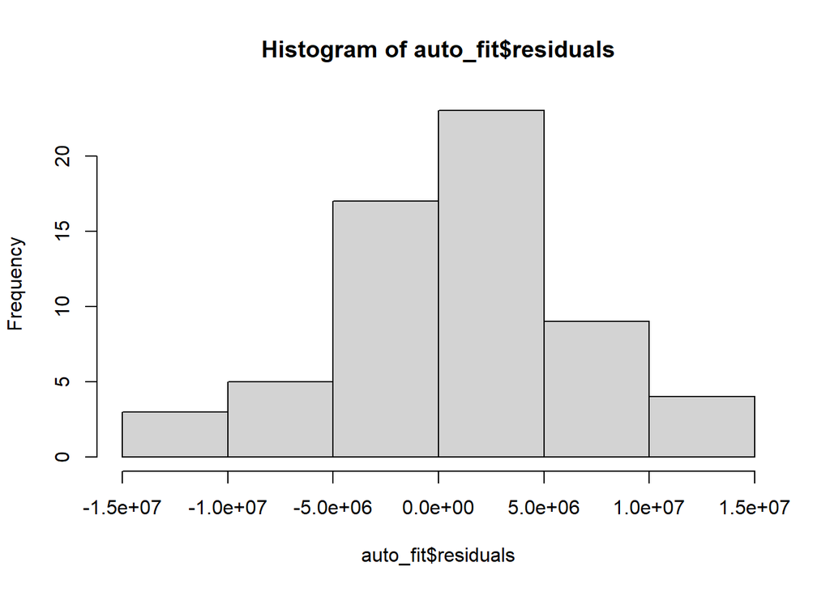

```r
hist(auto_fit$residuals)
```

#Histogram suggests that residuals may not be normal. Right tail seems to be little long. However, p-value is non-significant (>0.05), indicating that there is no significant correlation in residuals of time series. Hence, this method wcan be considered quite appropriate for forecasting.